# Life Expectancy Analysis

#### Life Expectancy Vs Mortality Factors : Adult Mortality, Infant deaths, under 5 deaths and deaths due to HIV/AIDS

Plotting the required visualization.

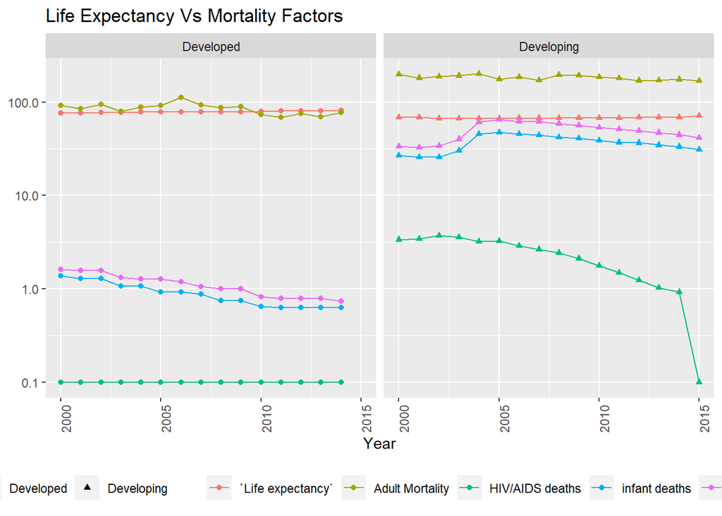

```r
global %>%
  ggplot(aes(x = Year, y =`Life expectancy` )) +
  geom_line(aes(color = "`Life expectancy`" )) +
  geom_point(aes(color = "`Life expectancy`", shape = global$Status)) +
  geom_line(aes(y = `Adult Mortality`, color = "Adult Mortality")) +
  geom_point(aes(y = `Adult Mortality`, color = "Adult Mortality", shape= global$Status)) +
  geom_line(aes(y = `infant deaths`, color = "infant deaths")) +
  geom_point(aes(y = `infant deaths`, color = "infant deaths", shape = global$Status)) +
  geom_line(aes(y = `under-five deaths`, color = "under-five deaths")) +
  geom_point(aes(y = `under-five deaths`, color = "under-five deaths", shape = global$Status)) +
  geom_line(aes(y = `HIV/AIDS`, color = "HIV/AIDS deaths")) +
  geom_point(aes(y = `HIV/AIDS`, color = "HIV/AIDS deaths", shape = global$Status)) +
  scale_y_log10() +
  facet_wrap(~Status) +
  labs(shape = "Type", color = NULL) +
  theme(legend.position="bottom",
        axis.text.x = element_text(angle = 90)) +
  labs(title = "Life Expectancy Vs Mortality Factors", y= NULL)
```

**Analysing the above Plots**

-As can be seen from the plots, Developing nations have much higher mortality rates as compared to developed countries. Hence, all three mortality rates(Adult, infant and under-five) have a negative correlation with Life Expectancy. - The infant mortality rates and under-5-mortality rates are almost parallel curves suggesting similar factors like poor nutrition,level of vaccination, neonatal care etc. are at play. -The deaths due to HIV/AIDS are also significantly higher in developing countries resulting into higher overall mortality rates in them. But the Deaths due to HIV/AIDS are showing a decreasing trend with timein developing nations which can be one of the reasons for increasing Life expectancy with time.

#### Average Life Expectancy Vs Immunization Factors.

Considering immunization of 1year old child as the benchmark and vaccinations of Hepatitis B, Polio and Diphtheria as index.

Plotting the required visualization.

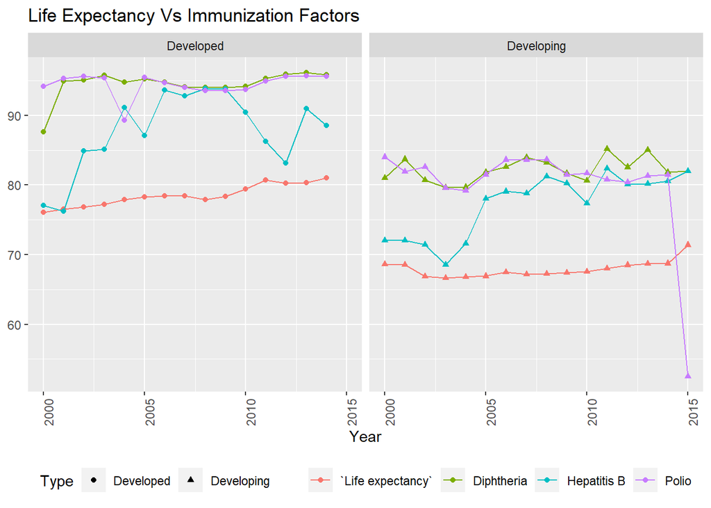

```r
global %>%
  ggplot(aes(x = Year, y =`Life expectancy` )) +
  geom_line(aes(color = "`Life expectancy`" )) +
  geom_point(aes(color = "`Life expectancy`", shape = global$Status)) +
  geom_line(aes(y = `Diphtheria`, color = "Diphtheria")) +
  geom_point(aes(y = `Diphtheria`, color = "Diphtheria", shape= global$Status)) +
  geom_line(aes(y = `Hepatitis B`, color = "Hepatitis B")) +
  geom_point(aes(y = `Hepatitis B`, color = "Hepatitis B", shape = global$Status)) +
  geom_line(aes(y = `Polio`, color = "Polio")) +
  geom_point(aes(y = `Polio`, color = "Polio", shape = global$Status)) +
  facet_wrap(~Status) +
  labs(shape = "Type", color = NULL) +
  theme(legend.position="bottom",
        axis.text.x = element_text(angle = 90)) +
  labs(title = "Life Expectancy Vs Immunization Factors", y= NULL)
```

**Analysis of the above plots** .

- The above curve does not show any definite trend, specially in the data of Hepatitis-B vaccination. Hence no direct corelation with the LIfe expectancy is clear.
- But one good observation is that overall there is higher level of immunization in the developed countries as compared to developing one, which can be a factor for higher Life expectancy of developed world.

#### Average Life Expectancy Vs Economic Factors.

Looking at the various economic factors like % expenditure, Total Expenditure, GDP of the nation and income composition

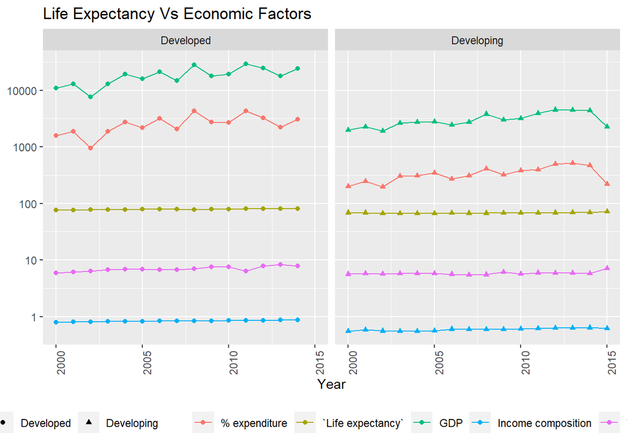

```r
global %>%
  ggplot(aes(x = Year, y =`Life expectancy` )) +
  geom_line(aes(color = "`Life expectancy`" )) +
  geom_point(aes(color = "`Life expectancy`", shape = global$Status)) +
  geom_line(aes(y = `percentage expenditure`, color = "% expenditure")) +
  geom_point(aes(y = `percentage expenditure`, color = "% expenditure", shape= global$Status)) +
  geom_line(aes(y = `Total expenditure`, color = "Total expenditure")) +
  geom_point(aes(y = `Total expenditure`, color = "Total expenditure", shape = global$Status)) +
  geom_line(aes(y = `Income composition of resources`, color = "Income composition")) +
  geom_point(aes(y = `Income composition of resources`, color = "Income composition", shape = global$Status)) +
  geom_line(aes(y = GDP, color = "GDP")) +
  geom_point(aes(y = GDP, color = "GDP", shape= global$Status)) +
  facet_wrap(~Status) +
  scale_y_log10() +
  labs(shape = "Type", color = NULL) +
  theme(legend.position="bottom",
        axis.text.x = element_text(angle = 90)) +
  labs(title = "Life Expectancy Vs Economic Factors", y= NULL)
```

**Analysing the above Plots.**

As can be seen from the graphs :

- All the economic factors have a positive correlation with the Life expectancy. This suggests better the fiscal health of the nation –> better is the expenditure on health infrastructure and services –> better is the Life expectancy.
- Also, as expected developed nations have stronger fiscal health as compared to developing nations.

### Global Life Expectancy Analysis : Country Wise

Preparing copies of data in relevant format. - data_countries : country-wise avg statistics over the period of 2000 to 2015 - d2 : a copy of data_countries with a shorter name.

```r
data_countries <- data_clean %>%group_by(Country,Status)%>% select(-c(Year))%>% summarise_each(funs( mean(.,na.rm = TRUE)))%>%ungroup()
ungroup(data_clean)
```

```
## # A tibble: 1,649 x 22
##    Country      Year Status     `Life expectanc~ `Adult Mortalit~ `infant deaths`
##    <chr>       <dbl> <chr>                 <dbl>            <dbl>           <dbl>
##  1 Afghanistan  2015 Developing             65                263              62
##  2 Afghanistan  2014 Developing             59.9              271              64
##  3 Afghanistan  2013 Developing             59.9              268              66
##  4 Afghanistan  2012 Developing             59.5              272              69
##  5 Afghanistan  2011 Developing             59.2              275              71
##  6 Afghanistan  2010 Developing             58.8              279              74
##  7 Afghanistan  2009 Developing             58.6              281              77
##  8 Afghanistan  2008 Developing             58.1              287              80
##  9 Afghanistan  2007 Developing             57.5              295              82
## 10 Afghanistan  2006 Developing             57.3              295              84
## # ... with 1,639 more rows, and 16 more variables: Alcohol <dbl>,
## #   percentage expenditure <dbl>, Hepatitis B <dbl>, Measles <dbl>, BMI <dbl>,
## #   under-five deaths <dbl>, Polio <dbl>, Total expenditure <dbl>,
## #   Diphtheria <dbl>, HIV/AIDS <dbl>, GDP <dbl>, Population <dbl>,
## #   thinness  1-19 years <dbl>, thinness 5-9 years <dbl>,
## #   Income composition of resources <dbl>, Schooling <dbl>
```

```r
print(data_countries)
```

```
## # A tibble: 133 x 21
##    Country     Status  `Life expectanc~ `Adult Mortalit~ `infant deaths` Alcohol
##    <chr>       <chr>              <dbl>            <dbl>           <dbl>   <dbl>
##  1 Afghanistan Develo~             58.2            269.           78.2    0.0144
##  2 Albania     Develo~             75.2             45.1           0.688  4.85
##  3 Algeria     Develo~             74.2            103.           20.3    0.447
##  4 Angola      Develo~             50.7            363.           76.6    7.62
##  5 Argentina   Develo~             75.2            100.           10      8.00
##  6 Armenia     Develo~             73.3            117.            1      3.70
##  7 Australia   Develo~             81.9             62.4           1     10.2
##  8 Austria     Develo~             81.5             65.8           0     12.2
##  9 Azerbaijan  Develo~             71.1            120.            5.77   1.06
## 10 Bangladesh  Develo~             70.0            136.          142.     0.01
## # ... with 123 more rows, and 15 more variables: percentage expenditure <dbl>,
## #   Hepatitis B <dbl>, Measles <dbl>, BMI <dbl>, under-five deaths <dbl>,
## #   Polio <dbl>, Total expenditure <dbl>, Diphtheria <dbl>, HIV/AIDS <dbl>,
## #   GDP <dbl>, Population <dbl>, thinness  1-19 years <dbl>,
## #   thinness 5-9 years <dbl>, Income composition of resources <dbl>,
## #   Schooling <dbl>
```

#### Global Average Life Expectancy.

Finding the mean life expectancy for all the people across globe, averaged over the period of 2000-2015

The finding is : 68.62 years

```r
d2<- data_countries
global_avg_LE = mean(d2$`Life expectancy`)
print(global_avg_LE)
```

```
## [1] 68.62162
```

#### Top 10 countries with **highest Life expectancy** across globe, averaged over the period of 2000-2015

```r
d2%>% slice_max(`Life expectancy`, n = 10)
```

```
## # A tibble: 10 x 21
##    Country     Status  `Life expectanc~ `Adult Mortalit~ `infant deaths` Alcohol
##    <chr>       <chr>              <dbl>            <dbl>           <dbl>   <dbl>
##  1 Ireland     Develo~             83.4             55.4            0      11.3
##  2 Canada      Develo~             82.2             66.8            2       8.16
##  3 France      Develo~             82.2             72.8            3      12.4
##  4 Italy       Develo~             82.2             54.1            2.07    8.27
##  5 Spain       Develo~             82.0             64.1            1.67   10.0
##  6 Australia   Develo~             81.9             62.4            1      10.2
##  7 Sweden      Develo~             81.9             56.5            0       7.35
##  8 Austria     Develo~             81.5             65.8            0      12.2
##  9 Netherlands Develo~             81.3             47.2            1       6.68
## 10 Greece      Develo~             81.2             73.7            0.2     8.80
## # ... with 15 more variables: percentage expenditure <dbl>, Hepatitis B <dbl>,
## #   Measles <dbl>, BMI <dbl>, under-five deaths <dbl>, Polio <dbl>,
## #   Total expenditure <dbl>, Diphtheria <dbl>, HIV/AIDS <dbl>, GDP <dbl>,
## #   Population <dbl>, thinness  1-19 years <dbl>, thinness 5-9 years <dbl>,
## #   Income composition of resources <dbl>, Schooling <dbl>
```

As can be seen from the above table of Highest Life expectancy, Ireland tops the chart with avg. Life expectancy of about 83 years.Moreover, all the 10 nations in the list are from the first world nations which are either already well developed or just about to enter the status of being developed. Apart from this , all 10 nations have Avg. Life expectancy over 80yrs, which is way more higher than the global avg. of 68.62 avy across globe over the same time period of 2000 -2015

#### Top 10 countries with the **least Life expectancy** across globe, averaged over the period of 2000-2015

```r
d2%>% slice_min(`Life expectancy`, n = 10)
```

```
## # A tibble: 10 x 21
##    Country     Status  `Life expectanc~ `Adult Mortalit~ `infant deaths` Alcohol
##    <chr>       <chr>              <dbl>            <dbl>           <dbl>   <dbl>
##  1 Sierra Leo~ Develo~             48.4             335.           26.2    2.42
##  2 Lesotho     Develo~             48.6             547.            4.42   1.87
##  3 Zimbabwe    Develo~             49.4             471.           26.9    4.48
##  4 Malawi      Develo~             50.3             403            36.1    0.882
##  5 Angola      Develo~             50.7             363.           76.6    7.62
##  6 Swaziland   Develo~             50.8             337.            2.67   4.46
##  7 Central Af~ Develo~             51.4             445.           16.2    0.82
##  8 Chad        Develo~             52.3             322.           46      0.464
##  9 Nigeria     Develo~             52.8             340.          524.     8.18
## 10 Mozambique  Develo~             53.4             230.           74.3    1.27
## # ... with 15 more variables: percentage expenditure <dbl>, Hepatitis B <dbl>,
## #   Measles <dbl>, BMI <dbl>, under-five deaths <dbl>, Polio <dbl>,
## #   Total expenditure <dbl>, Diphtheria <dbl>, HIV/AIDS <dbl>, GDP <dbl>,
## #   Population <dbl>, thinness  1-19 years <dbl>, thinness 5-9 years <dbl>,
## #   Income composition of resources <dbl>, Schooling <dbl>
```

As can be seen from the table above :-

- Sierra Leone tops the chart with Life Expectancy as low as 48yrs, which is almost 20yrs lower than the global avg of 68 yrs.
- All the 10 countries are developing nations and all belong to the continent of Africa.

#### **Probability density function** of global Avg. Life Expectancies :

Ploting the pdf curve :

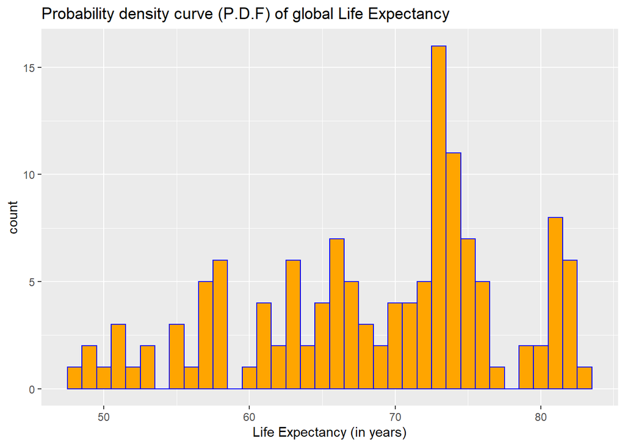

```r
p<-ggplot(d2, aes(x=`Life expectancy`)) +
  geom_histogram(binwidth=1, color="Blue", fill="orange") +
  labs( title = "Probability density curve (P.D.F) of global Life Expectancy" , x = "Life Expectancy (in years)")
print(p)
```

According to the Probability density function (pdf) of Avg Life expectancy of different countries over the period of 2000-2015, one can conclude that the most likely average global expected Life expectancy is about **73 year**. Also, the highest Life expectancy across globe is 83yrs which is about 10 years more than the modal value of 73ys.

### Country-wise comparison of top performers : in terms of LIfe Expectancy

Preparing copies of data in relevant format. - d3 : a copy of data_clean with a shorter name. - d3_2005 : country wise data for the year 2005 - d3_2014 : country wise data for the year 2014

```r
d3<-data_clean
d3_2005<-d3 %>% filter(Year == 2005 )
d3_2014<-d3 %>% filter(Year == 2014 )

print(d3)
```

```
## # A tibble: 1,649 x 22
##    Country      Year Status     `Life expectanc~ `Adult Mortalit~ `infant deaths`
##    <chr>       <dbl> <chr>                 <dbl>            <dbl>           <dbl>
##  1 Afghanistan  2015 Developing             65                263              62
##  2 Afghanistan  2014 Developing             59.9              271              64
##  3 Afghanistan  2013 Developing             59.9              268              66
##  4 Afghanistan  2012 Developing             59.5              272              69
##  5 Afghanistan  2011 Developing             59.2              275              71
##  6 Afghanistan  2010 Developing             58.8              279              74
##  7 Afghanistan  2009 Developing             58.6              281              77
##  8 Afghanistan  2008 Developing             58.1              287              80
##  9 Afghanistan  2007 Developing             57.5              295              82
## 10 Afghanistan  2006 Developing             57.3              295              84
## # ... with 1,639 more rows, and 16 more variables: Alcohol <dbl>,
## #   percentage expenditure <dbl>, Hepatitis B <dbl>, Measles <dbl>, BMI <dbl>,
## #   under-five deaths <dbl>, Polio <dbl>, Total expenditure <dbl>,
## #   Diphtheria <dbl>, HIV/AIDS <dbl>, GDP <dbl>, Population <dbl>,
## #   thinness  1-19 years <dbl>, thinness 5-9 years <dbl>,
## #   Income composition of resources <dbl>, Schooling <dbl>
```

```r
print(d3_2005)
```

```
## # A tibble: 110 x 22
##    Country      Year Status     `Life expectanc~ `Adult Mortalit~ `infant deaths`
##    <chr>       <dbl> <chr>                 <dbl>            <dbl>           <dbl>
##  1 Afghanistan  2005 Developing             57.3              291              85
##  2 Albania      2005 Developing             73.5               15               1
##  3 Algeria      2005 Developing             72.9              136              19
##  4 Argentina    2005 Developing             74.9              127              11
##  5 Armenia      2005 Developing             73                137               1
##  6 Australia    2005 Developed              81                 67               1
##  7 Austria      2005 Developed              79.4               85               0
##  8 Azerbaijan   2005 Developing             68.4              162               6
##  9 Bangladesh   2005 Developing             67.8              155             174
## 10 Belarus      2005 Developing             68.1              252               1
## # ... with 100 more rows, and 16 more variables: Alcohol <dbl>,
## #   percentage expenditure <dbl>, Hepatitis B <dbl>, Measles <dbl>, BMI <dbl>,
## #   under-five deaths <dbl>, Polio <dbl>, Total expenditure <dbl>,
## #   Diphtheria <dbl>, HIV/AIDS <dbl>, GDP <dbl>, Population <dbl>,
## #   thinness  1-19 years <dbl>, thinness 5-9 years <dbl>,
## #   Income composition of resources <dbl>, Schooling <dbl>
```

```r
print(d3_2014)
```

```
## # A tibble: 131 x 22
##    Country      Year Status     `Life expectanc~ `Adult Mortalit~ `infant deaths`
##    <chr>       <dbl> <chr>                 <dbl>            <dbl>           <dbl>
##  1 Afghanistan  2014 Developing             59.9              271              64
##  2 Albania      2014 Developing             77.5                8               0
##  3 Algeria      2014 Developing             75.4               11              21
##  4 Angola       2014 Developing             51.7              348              67
##  5 Argentina    2014 Developing             76.2              118               8
##  6 Armenia      2014 Developing             74.6               12               1
##  7 Australia    2014 Developed              82.7                6               1
##  8 Austria      2014 Developed              81.4               66               0
##  9 Azerbaijan   2014 Developing             72.5              119               5
## 10 Bangladesh   2014 Developing             71.4              132              98
## # ... with 121 more rows, and 16 more variables: Alcohol <dbl>,
## #   percentage expenditure <dbl>, Hepatitis B <dbl>, Measles <dbl>, BMI <dbl>,
## #   under-five deaths <dbl>, Polio <dbl>, Total expenditure <dbl>,
## #   Diphtheria <dbl>, HIV/AIDS <dbl>, GDP <dbl>, Population <dbl>,
## #   thinness  1-19 years <dbl>, thinness 5-9 years <dbl>,
## #   Income composition of resources <dbl>, Schooling <dbl>
```

#### Plotting the best 5 performers of the year 2005

```r
Best_2005<- d3_2005 %>% slice_max(`Life expectancy`, n = 5)
print(Best_2005)
```

```
## # A tibble: 5 x 22
##   Country    Year Status `Life expectanc~ `Adult Mortalit~ `infant deaths` Alcohol
##   <chr>     <dbl> <chr>             <dbl>            <dbl>           <dbl>   <dbl>
## 1 Italy      2005 Devel~               88               66               2    8.65
## 2 Australia  2005 Devel~               81               67               1   10.3
## 3 Canada     2005 Devel~               81               76               2    8
## 4 France     2005 Devel~               81               93               3   12.2
## 5 Spain      2005 Devel~               81               77               2   11.9
## # ... with 15 more variables: percentage expenditure <dbl>, Hepatitis B <dbl>,
## #   Measles <dbl>, BMI <dbl>, under-five deaths <dbl>, Polio <dbl>,
## #   Total expenditure <dbl>, Diphtheria <dbl>, HIV/AIDS <dbl>, GDP <dbl>,
## #   Population <dbl>, thinness  1-19 years <dbl>, thinness 5-9 years <dbl>,
## #   Income composition of resources <dbl>, Schooling <dbl>
```

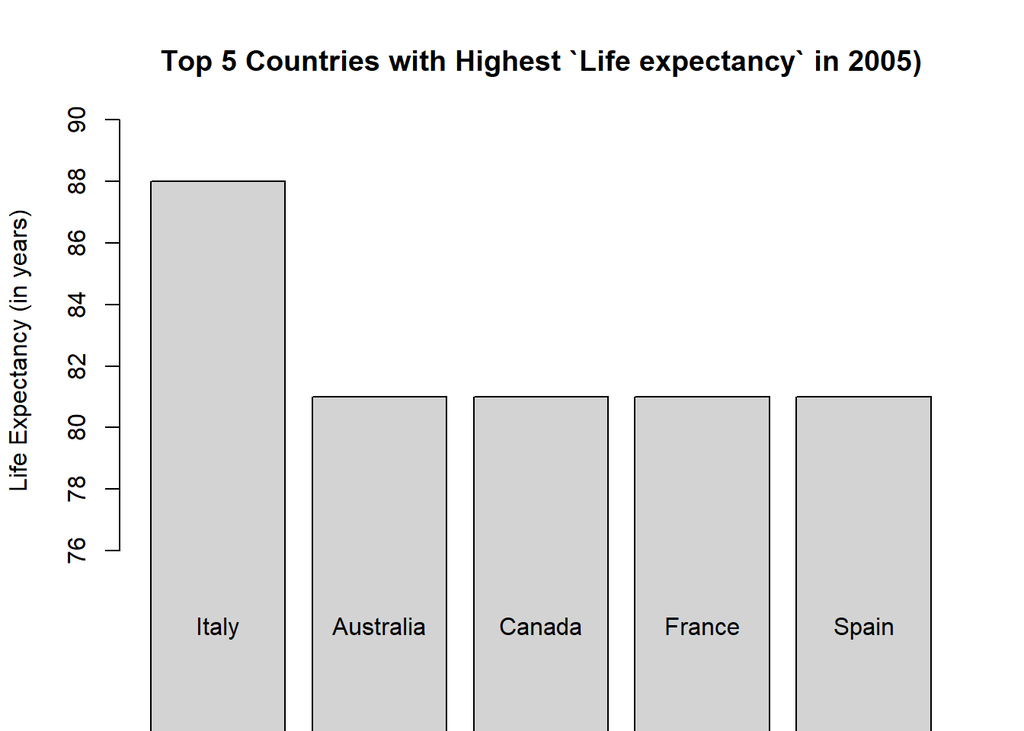

```r
barplot(Best_2005$`Life expectancy`,
main = "Top 5 Countries with Highest `Life expectancy` in 2005)",
ylab = "Life Expectancy (in years)",
ylim = c(75,90),
names.arg = c("Italy","Australia","Canada","France","Spain"),
col = "Light Grey",

horiz = F )
```

```r
Best_2014<- d3_2014 %>% slice_max(`Life expectancy`, n = 5)
print(Best_2014)
```

```
## # A tibble: 6 x 22
##   Country   Year Status `Life expectanc~ `Adult Mortalit~ `infant deaths` Alcohol
##   <chr>    <dbl> <chr>             <dbl>            <dbl>           <dbl>   <dbl>
## 1 Belgium   2014 Devel~               89               76               0   12.6
## 2 Germany   2014 Devel~               89               69               2   11.0
## 3 Portugal  2014 Devel~               89               78               0    9.88
## 4 Greece    2014 Devel~               88               73               0    7.53
## 5 Chile     2014 Devel~               83               83               2    7.16
## 6 Cyprus    2014 Devel~               83               53               0    0.01
## # ... with 15 more variables: percentage expenditure <dbl>, Hepatitis B <dbl>,
## #   Measles <dbl>, BMI <dbl>, under-five deaths <dbl>, Polio <dbl>,
## #   Total expenditure <dbl>, Diphtheria <dbl>, HIV/AIDS <dbl>, GDP <dbl>,
## #   Population <dbl>, thinness  1-19 years <dbl>, thinness 5-9 years <dbl>,
## #   Income composition of resources <dbl>, Schooling <dbl>
```

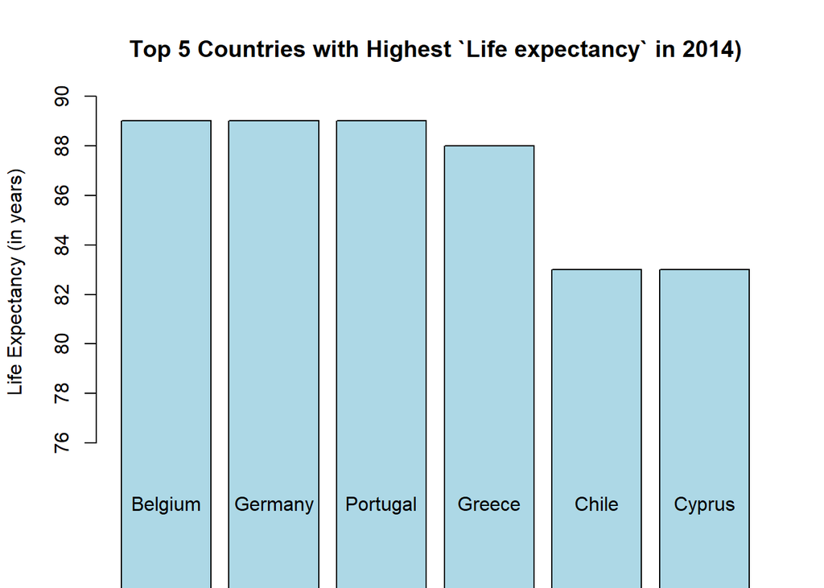

```r
barplot(Best_2014$`Life expectancy`,
main = "Top 5 Countries with Highest `Life expectancy` in 2014)",
ylab = "Life Expectancy (in years)",
ylim = c(75,90),
names.arg = c("Belgium","Germany","Portugal","Greece","Chile", "Cyprus"),
col = "Light Blue",

horiz = F )
```

- As can be seen from both the plots, the top performers are still from the first world nations , though the toppers of the past have failed to retain their positions in the chart.
- Also, as can be seen from the graphs, the Life expectancy value for the top performers is higher in 2014 as compared to 2005, which suggest that world as a whole is moving towards longevity of life.

## Linear Model to predict Life expectancy against the parameter of schooling.

```r
mod <- lm(`Life expectancy` ~ Schooling, data = global)
summary(mod)
```

```
##
## Call:
## lm(formula = `Life expectancy` ~ Schooling, data = global)
##
## Residuals:
##     Min      1Q  Median      3Q     Max
## -1.0657 -0.4495 -0.1901  0.3199  1.8481
##
## Coefficients:
##             Estimate Std. Error t value Pr(>|t|)
## (Intercept) 37.16285    0.78237   47.50   <2e-16 ***
## Schooling    2.66577    0.05747   46.38   <2e-16 ***
## ---
## Signif. codes:  0 '***' 0.001 '**' 0.01 '*' 0.05 '.' 0.1 ' ' 1
##
## Residual standard error: 0.6511 on 29 degrees of freedom
## Multiple R-squared:  0.9867, Adjusted R-squared:  0.9862
## F-statistic:  2152 on 1 and 29 DF,  p-value: < 2.2e-16
```

```r
x_grid <- seq(1, 151)
new_df <- tibble(Schooling = x_grid)
global %>% mutate(pred = predict(mod))
```

```
## # A tibble: 31 x 22
##     Year Status     `Life expectancy` `Adult Mortality` `infant deaths` Alcohol
##    <dbl> <chr>                  <dbl>             <dbl>           <dbl>   <dbl>
##  1  2000 Developed               76.1              91.7            1.38   10.6
##  2  2000 Developing              68.6             197.            26.7     3.76
##  3  2001 Developed               76.6              84.9            1.29   10.4
##  4  2001 Developing              68.6             181.            25.8     3.85
##  5  2002 Developed               76.9              94.9            1.29   10.7
##  6  2002 Developing              66.9             188.            25.7     3.81
##  7  2003 Developed               77.2              78.9            1.07   10.6
##  8  2003 Developing              66.7             191.            30.2     3.59
##  9  2004 Developed               77.9              87.8            1.07   10.9
## 10  2004 Developing              66.8             201.            45.7     3.67
## # ... with 21 more rows, and 16 more variables: percentage expenditure <dbl>,
## #   Hepatitis B <dbl>, Measles <dbl>, BMI <dbl>, under-five deaths <dbl>,
## #   Polio <dbl>, Total expenditure <dbl>, Diphtheria <dbl>, HIV/AIDS <dbl>,
## #   GDP <dbl>, Population <dbl>, thinness  1-19 years <dbl>,
## #   thinness 5-9 years <dbl>, Income composition of resources <dbl>,
## #   Schooling <dbl>, pred <dbl>
```

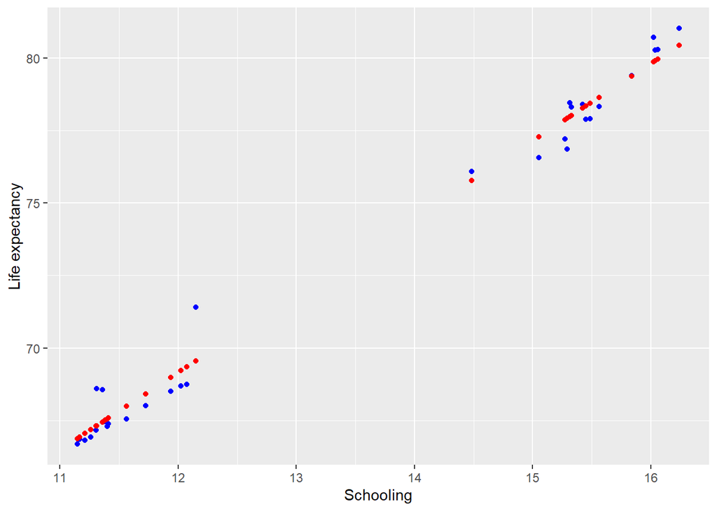

```r
LE_pred <- global %>% mutate(pred = predict(mod))
LE_pred %>% ggplot() +
geom_point(aes(x = Schooling, y = `Life expectancy`), color = "blue") +
geom_point(aes(x = Schooling, y = pred), color = "red")
```

As can be seen from the above graph : - the schooling has a positive correlation with LIfe Expectancy as the curve has a positive slope. - As both red and blue dots are majorly close, it suggests that linear model to find the correlation and prediction of Life expectancy is quite good.

# **CONCLUSION**

Avg. Life Expectancy of humans is not a naturally fixed constant but a variable being shaped by various anthropogenic factors too such as Lifestyle habits, spending on Health infrastructure and services, better immunization drives as well as other socio-economic and political factors. Hence, in order to lead a better and more longer life, humans need to define their public policy keeping various factors in mind as analysed above. Hence, with better policy and practices on the line of developed world , Humanity can lead a better, healthier and longer life.